# Hierarchical clustering

### Problem Statement:-

- Perform clustering (Both hierarchical and K means clustering) for the airlines data to obtain optimum number of clusters. Draw the inferences from the clusters obtained.

### Data Understanding and Preparation

```r
#Reading the dataset
library(readxl)
airlines <- read_excel("~/desktop/Digi 360/Module 12/EastWestAirlines.xlsx")
```

```r
head(airlines)
```

| ID# | Balance | Qual_miles | cc1_miles | cc2_miles | cc3_miles | Bonus_miles | Bonus_trans | Flight_miles_12mo | Flight_trans_12 | Days_since_enroll | Award? |
| --- | --- | --- | --- | --- | --- | --- | --- | --- | --- | --- | --- |
| 1 | 28143 | 0 | 1 | 1 | 1 | 174 | 1 | 0 | 0 | 7000 | 0 |
| 2 | 19244 | 0 | 1 | 1 | 1 | 215 | 2 | 0 | 0 | 6968 | 0 |
| 3 | 41354 | 0 | 1 | 1 | 1 | 4123 | 4 | 0 | 0 | 7034 | 0 |
| 4 | 14776 | 0 | 1 | 1 | 1 | 500 | 1 | 0 | 0 | 6952 | 0 |
| 5 | 97752 | 0 | 4 | 1 | 1 | 43300 | 26 | 2077 | 4 | 6935 | 1 |
| 6 | 16420 | 0 | 1 | 1 | 1 | 0 | 0 | 0 | 0 | 6942 | 0 |

```r
summary(airlines)
```

```
      ID#          Balance          Qual_miles        cc1_miles
 Min.   :   1   Min.   :      0   Min.   :    0.0   Min.   :1.00
 1st Qu.:1010   1st Qu.:  18528   1st Qu.:    0.0   1st Qu.:1.00
 Median :2016   Median :  43097   Median :    0.0   Median :1.00
 Mean   :2015   Mean   :  73601   Mean   :  144.1   Mean   :2.06
 3rd Qu.:3020   3rd Qu.:  92404   3rd Qu.:    0.0   3rd Qu.:3.00
 Max.   :4021   Max.   :1704838   Max.   :11148.0   Max.   :5.00
   cc2_miles       cc3_miles      Bonus_miles      Bonus_trans
 Min.   :1.000   Min.   :1.000   Min.   :     0   Min.   : 0.0
 1st Qu.:1.000   1st Qu.:1.000   1st Qu.:  1250   1st Qu.: 3.0
 Median :1.000   Median :1.000   Median :  7171   Median :12.0
 Mean   :1.015   Mean   :1.012   Mean   : 17145   Mean   :11.6
 3rd Qu.:1.000   3rd Qu.:1.000   3rd Qu.: 23800   3rd Qu.:17.0
 Max.   :3.000   Max.   :5.000   Max.   :263685   Max.   :86.0
 Flight_miles_12mo Flight_trans_12  Days_since_enroll     Award?
 Min.   :    0.0   Min.   : 0.000   Min.   :   2      Min.   :0.0000
 1st Qu.:    0.0   1st Qu.: 0.000   1st Qu.:2330      1st Qu.:0.0000
 Median :    0.0   Median : 0.000   Median :4096      Median :0.0000
 Mean   :  460.1   Mean   : 1.374   Mean   :4119      Mean   :0.3703
 3rd Qu.:  311.0   3rd Qu.: 1.000   3rd Qu.:5790      3rd Qu.:1.0000
 Max.   :30817.0   Max.   :53.000   Max.   :8296      Max.   :1.0000
```

```r
any(is.na(airlines))
```

```
[1] FALSE
```

### Scaling

Before applying Hierarchical Clustering, we have to normalize the data so that the scale of each variable is the same. Why is this important? Well, if the scale of the variables is not the same, the model might become biased towards the variables with a higher magnitude.

```r
airlines_scaled <- as.data.frame(scale(airlines))
summary(airlines_scaled)
```

```
      ID#               Balance          Qual_miles        cc1_miles
 Min.   :-1.734908   Min.   :-0.7303   Min.   :-0.1863   Min.   :-0.7695
 1st Qu.:-0.865223   1st Qu.:-0.5465   1st Qu.:-0.1863   1st Qu.:-0.7695
 Median : 0.001017   Median :-0.3027   Median :-0.1863   Median :-0.7695
 Mean   : 0.000000   Mean   : 0.0000   Mean   : 0.0000   Mean   : 0.0000
 3rd Qu.: 0.866395   3rd Qu.: 0.1866   3rd Qu.:-0.1863   3rd Qu.: 0.6830
 Max.   : 1.728327   Max.   :16.1868   Max.   :14.2231   Max.   : 2.1356
   cc2_miles          cc3_miles         Bonus_miles       Bonus_trans
 Min.   :-0.09823   Min.   :-0.06276   Min.   :-0.7099   Min.   :-1.20805
 1st Qu.:-0.09823   1st Qu.:-0.06276   1st Qu.:-0.6581   1st Qu.:-0.89568
 Median :-0.09823   Median :-0.06276   Median :-0.4130   Median : 0.04145
 Mean   : 0.00000   Mean   : 0.00000   Mean   : 0.0000   Mean   : 0.00000
 3rd Qu.:-0.09823   3rd Qu.:-0.06276   3rd Qu.: 0.2756   3rd Qu.: 0.56208
 Max.   :13.44729   Max.   :20.42477   Max.   :10.2083   Max.   : 7.74673
 Flight_miles_12mo Flight_trans_12    Days_since_enroll      Award?
 Min.   :-0.3286   Min.   :-0.36212   Min.   :-1.99336   Min.   :-0.7668
 1st Qu.:-0.3286   1st Qu.:-0.36212   1st Qu.:-0.86607   1st Qu.:-0.7668
 Median :-0.3286   Median :-0.36212   Median :-0.01092   Median :-0.7668
 Mean   : 0.0000   Mean   : 0.00000   Mean   : 0.00000   Mean   : 0.0000
 3rd Qu.:-0.1065   3rd Qu.:-0.09849   3rd Qu.: 0.80960   3rd Qu.: 1.3038
 Max.   :21.6803   Max.   :13.61035   Max.   : 2.02284   Max.   : 1.3038
```

### Building the Model

```r
dist_mat <- dist(airlines_scaled, method = 'euclidean')
hclust_ward <- hclust(dist_mat, method = 'ward.D2')
```

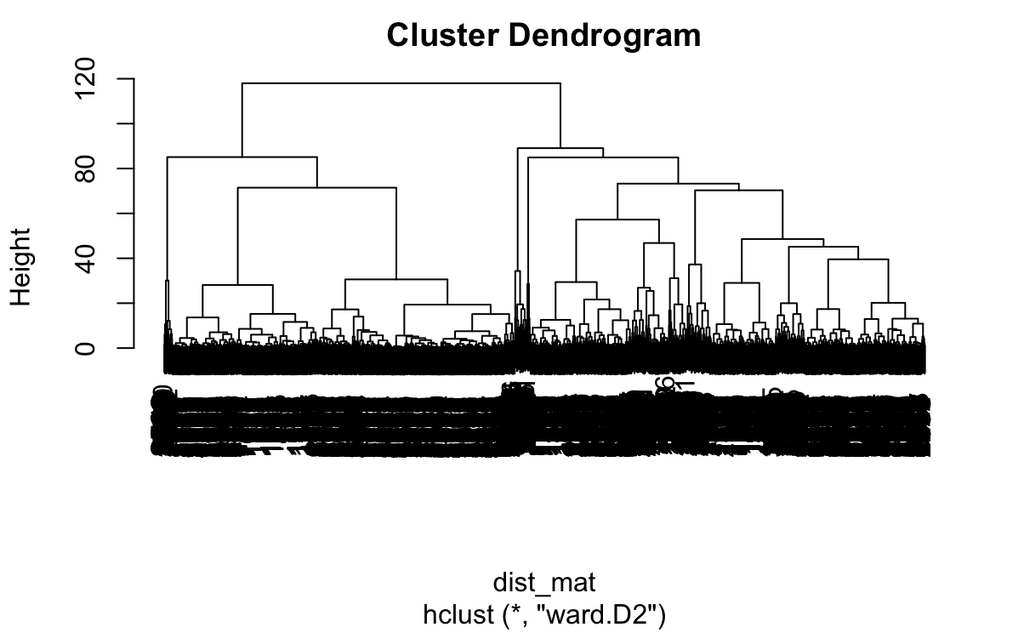

```r
#Plotting the dendrogram
plot(hclust_ward)
```

### Cutting the Dendrogram

```r
cut_ward <- cutree(hclust_ward, k = 5)
```

```r
plot(hclust_ward)
rect.hclust(hclust_ward , k = 5, border = 2:6)
```

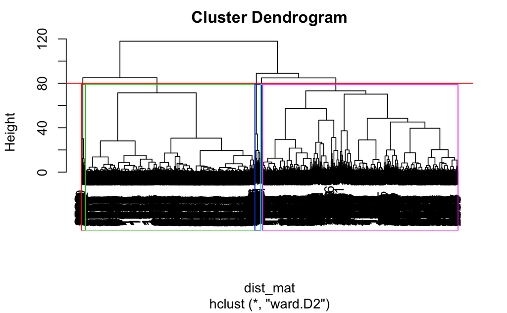

```r
abline(h = 80, col = 'red')
```

Let’s visualize the tree with different colored branches using package `dendextend`

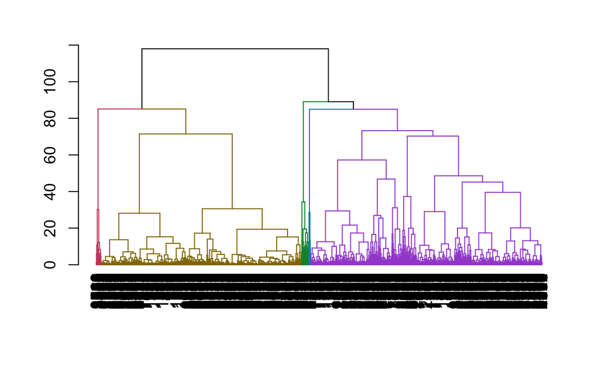

```r
suppressPackageStartupMessages(library(dendextend))
ward_dend_obj <- as.dendrogram(hclust_ward)
ward_col_dend <- color_branches(ward_dend_obj, h = 80)
plot(ward_col_dend)
```

```r
#Appending the clusters to original dataframe.
suppressPackageStartupMessages(library(dplyr))
airlines_cl <- mutate(airlines, cluster = cut_ward)
```

```r
head(airlines_cl)
```

| ID# | Balance | Qual_miles | cc1_miles | cc2_miles | cc3_miles | Bonus_miles | Bonus_trans | Flight_miles_12mo | Flight_trans_12 | Days_since_enroll | Award? | cluster |
| --- | --- | --- | --- | --- | --- | --- | --- | --- | --- | --- | --- | --- |
| 1 | 28143 | 0 | 1 | 1 | 1 | 174 | 1 | 0 | 0 | 7000 | 0 | 1 |
| 2 | 19244 | 0 | 1 | 1 | 1 | 215 | 2 | 0 | 0 | 6968 | 0 | 1 |
| 3 | 41354 | 0 | 1 | 1 | 1 | 4123 | 4 | 0 | 0 | 7034 | 0 | 1 |
| 4 | 14776 | 0 | 1 | 1 | 1 | 500 | 1 | 0 | 0 | 6952 | 0 | 1 |
| 5 | 97752 | 0 | 4 | 1 | 1 | 43300 | 26 | 2077 | 4 | 6935 | 1 | 2 |
| 6 | 16420 | 0 | 1 | 1 | 1 | 0 | 0 | 0 | 0 | 6942 | 0 | 1 |

### Visualizing few attributes

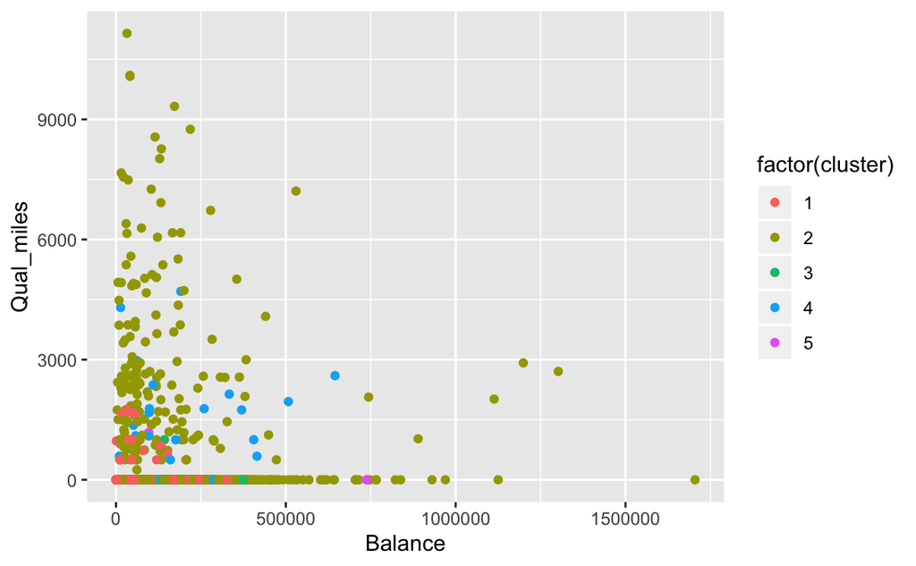

```r
suppressPackageStartupMessages(library(ggplot2))
ggplot(airlines_cl, aes(x=Balance, y = Qual_miles, color = factor(cluster))) + geom_point()
```

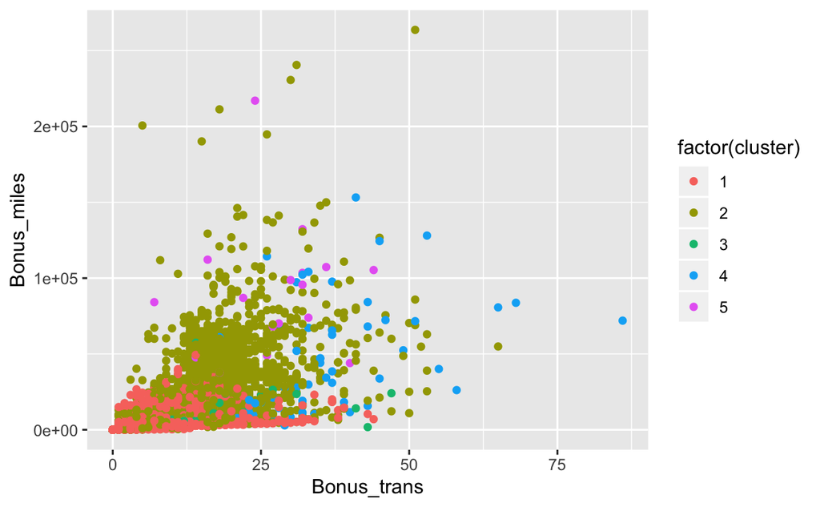

```r
suppressPackageStartupMessages(library(ggplot2))
ggplot(airlines_cl, aes(x=Bonus_trans, y = Bonus_miles, color = factor(cluster))) + geom_point()
```

```r
#Writing the final file with assigned cluster IDs.
write.csv(airlines_cl, file="~/desktop/Digi 360/Module 12/airlines_final_R.csv")
```

### Conclusion

- Chosen the threshold as 80 to cut the dendrogram considering above this threshold is maximum distance.
- The cut-off line is intersecting at five points in dendrogram, so 5 clusters have been chosen.